# Machine Learning Course project

Giorgos Mintzopoulos

August 20, 2015

## Introduction

This assignment is part of the Coursera Course “Practical Machine Learning”.

## Scope

Using devices such as Jawbone Up, Nike FuelBand, and Fitbit it is now possible to collect a large amount of data about personal activity. These type of devices are part of the quantified self movement – a group of enthusiasts who take measurements about themselves regularly to improve their health, to find patterns in their behavior, or because they are tech geeks. One thing that people regularly do is quantify how much of a particular activity they do, but they rarely quantify how well they do it. In this project, the goal is to use data from accelerometers on the belt, forearm, arm, and dumbell of 6 participants. They were asked to perform barbell lifts correctly and incorrectly in 5 different ways. More information is available from the website [Groupware@LES Human Activity Recognition](http://groupware.les.inf.puc-rio.br/har) *see the section on the Weight Lifting Exercise Dataset*.

The goal is to predict the manner in which they did the exercise. This is the “classe” variable in the training set. We may use any of the other variables to predict with. We will build a prediction model and will use it to predict 20 different test cases.

## Datasets

A training and a test dataset are given for this project and can be dowloaded from the internet using the code:

```r
library(curl, quietly=T)
train_url <- curl("https://d396qusza40orc.cloudfront.net/predmachlearn/pml-training.csv")
test_url <- curl("https://d396qusza40orc.cloudfront.net/predmachlearn/pml-testing.csv")

pml_data <- read.csv(train_url, header = T, sep = ",",  na.strings = c("", "NA", "#DIV/0!"))  # training data set
pml_testing <- read.csv(test_url, header = T, sep = ",",  na.strings = c("", "NA", "#DIV/0!"))  # testing data set
```

A large number of observations contain NA, empty and invalid values. All these have been loaded as NA using the na.strings = c(“”, “NA”, “#DIV/0!”) option shown in the code above.

## Data preprocessing

We can see that the dimensions of our data are,

```r
dim(pml_data)
```

```
## [1] 19622   160
```

We have 159 possible predictors for this **classification** problem to predict the exercise manner which is of data type factor with 5 levels, named “classe”.

```r
class(pml_data$classe); levels(pml_data$classe)
```

```
## [1] "factor"
```

```
## [1] "A" "B" "C" "D" "E"
```

Since all these variables refer to body movement measurements from different sensors during movement, will be likely high correlated. We will use different classification tree algorithms in our approach, because they are resistant to multicolinearity, and they don’t impose any heavy data preprocessing steps.

Note that, in general, the functions in the caret package that we will use, assume that there are no missing values in the data or that these values have been handled via imputation or other means.

We next eliminate all columns with NA variables and will base our predictions on the remaining variables, to see if we get a good accuracy level. Also we will exclude any near-zero variance predictors, because a tree based model is impervious to this predictor type since it would never be used in a split.

```r
#load caret package
library(caret)
```

```r
# Since the data set is large I am going to ommit as predictors the columns with NAs
na <- apply(pml_data, 2, is.na)
sumna <- apply(na, 2, sum)
index <- which(sumna != 0)

# I am also ommiting the irrelevat columns that keep logisitc info for the subjects {columns 1:7}
pml_data <- subset(pml_data, select = - c(1:7, index))
pml_testing <- subset(pml_testing, select = - c(1:7, index))

# next I filter for near-zero variance predictors, since a tree based model (classification) ...
# is impervious to this type of predictor since it would never be used in a split.
index <- nearZeroVar(pml_data)
if (length(index) != 0) {
  sprintf("Found %d near-zero variance predictors", length(index))
  pml_data <- subset(pml_data, select = -c(index))
  pml_testing <- subset(pml_data, select = -c(index))
} else {sprintf("Did not find any near-zero variance predictors")}
```

```
## [1] "Did not find any near-zero variance predictors"
```

The dimensions of the data sets we will use are therefore:

```r
dim(pml_data)
```

```
## [1] 19622    53
```

## Using Cross-Validation

We will use a typical cross-validation split of the pml_data dataset into a training set (60% of the observations) and validation dataset (remaining 40%). We do this using the caret package.

```r
# split the training set into myTraining 60% and myValidation 40% sets
inTrain <- createDataPartition(y = pml_data$classe, p = 0.6, list = F)
training <- pml_data[inTrain, ]
validation <- pml_data[-inTrain, ]
# vector of predictors
predictors <- names(pml_data)[names(pml_data) != "classe"]
rm(pml_data) # this in no longer needed
```

Our predictor variables are the following:

```r
predictors
```

```
##  [1] "roll_belt"            "pitch_belt"           "yaw_belt"
##  [4] "total_accel_belt"     "gyros_belt_x"         "gyros_belt_y"
##  [7] "gyros_belt_z"         "accel_belt_x"         "accel_belt_y"
## [10] "accel_belt_z"         "magnet_belt_x"        "magnet_belt_y"
## [13] "magnet_belt_z"        "roll_arm"             "pitch_arm"
## [16] "yaw_arm"              "total_accel_arm"      "gyros_arm_x"
## [19] "gyros_arm_y"          "gyros_arm_z"          "accel_arm_x"
## [22] "accel_arm_y"          "accel_arm_z"          "magnet_arm_x"
## [25] "magnet_arm_y"         "magnet_arm_z"         "roll_dumbbell"
## [28] "pitch_dumbbell"       "yaw_dumbbell"         "total_accel_dumbbell"
## [31] "gyros_dumbbell_x"     "gyros_dumbbell_y"     "gyros_dumbbell_z"
## [34] "accel_dumbbell_x"     "accel_dumbbell_y"     "accel_dumbbell_z"
## [37] "magnet_dumbbell_x"    "magnet_dumbbell_y"    "magnet_dumbbell_z"
## [40] "roll_forearm"         "pitch_forearm"        "yaw_forearm"
## [43] "total_accel_forearm"  "gyros_forearm_x"      "gyros_forearm_y"
## [46] "gyros_forearm_z"      "accel_forearm_x"      "accel_forearm_y"
## [49] "accel_forearm_z"      "magnet_forearm_x"     "magnet_forearm_y"
## [52] "magnet_forearm_z"
```

By default the caret package uses Bootstrap with 25 iterations used as the resampling scheme and we will use this setting here along with parallel processing on 2 cores, to permit model training in a reasonable amount of time for our computer setting (*laptop with 2-core, i7 @ 2.4 GHz and 8 Gb RAM*). *We can also enable parallel processing using the code to speed up the runing time (not done in this execution though):*

```r
library(doMC)
registerDoMC(cores = 2)
```

## Model fitting using caret and randomForest packages

We will fit several tree models to see the accuracy they provide. Namely we will fit:

| Model | Method | Package |
| --- | --- | --- |
| CART | rpart | caret |
| Bagging | treebag | caret |
| Random Forest | rf | randomForest |
| Ranodm Forest | rf | caret |
| Boosted | gbm | caret |

The default performance metrics and other option for classification will be used in the caret train function. We use accuracy as reported from the confusionMatrix function to select the better algorithm to use. This is not a strict model comparison as this would require the same settings for all models (parameters, training samples), as this is not our objective here. Our approach is to use the model reporting a very high accuracy on the prediction using the validation set, and runs in a reasonable amount of time.

*Note: The ConfusionMAtrix() functions calculates a cross-tabulation of observed and predicted classes with associated statistics.*

### Classification And Regression Tree

```r
#CART; method = raprt
system.time(
  fit_cart <- train(classe ~., method = "rpart", data = training)
)
```

```
##    user  system elapsed
##  12.208   0.027  12.225
```

```r
fit_cart
```

```
## CART
##
## 11776 samples
##    52 predictors
##     5 classes: 'A', 'B', 'C', 'D', 'E'
##
## No pre-processing
## Resampling: Bootstrapped (25 reps)
## Summary of sample sizes: 11776, 11776, 11776, 11776, 11776, 11776, ...
## Resampling results across tuning parameters:
##
##   cp          Accuracy   Kappa       Accuracy SD  Kappa SD
##   0.03796868  0.4961945  0.34417780  0.04697350   0.07772061
##   0.05841639  0.4005245  0.18198207  0.05529067   0.09358329
##   0.11426198  0.3373870  0.07926973  0.04225410   0.06081400
##
## Accuracy was used to select the optimal model using  the largest value.
## The final value used for the model was cp = 0.03796868.
```

```r
confusionMatrix(validation$classe, predict(fit_cart, validation))
```

```
## Confusion Matrix and Statistics
##
##           Reference
## Prediction    A    B    C    D    E
##          A 2037   25  165    0    5
##          B  640  522  356    0    0
##          C  610   40  718    0    0
##          D  572  240  474    0    0
##          E  203  190  390    0  659
##
## Overall Statistics
##
##                Accuracy : 0.5017
##                  95% CI : (0.4905, 0.5128)
##     No Information Rate : 0.5177
##     P-Value [Acc > NIR] : 0.9979
##
##                   Kappa : 0.3489
##  Mcnemar's Test P-Value : NA
##
## Statistics by Class:
##
##                      Class: A Class: B Class: C Class: D Class: E
## Sensitivity            0.5015  0.51327  0.34142       NA  0.99247
## Specificity            0.9485  0.85415  0.88682   0.8361  0.89098
## Pos Pred Value         0.9126  0.34387  0.52485       NA  0.45700
## Neg Pred Value         0.6393  0.92178  0.78620       NA  0.99922
## Prevalence             0.5177  0.12962  0.26803   0.0000  0.08463
## Detection Rate         0.2596  0.06653  0.09151   0.0000  0.08399
## Detection Prevalence   0.2845  0.19347  0.17436   0.1639  0.18379
## Balanced Accuracy      0.7250  0.68371  0.61412       NA  0.94172
```

This simple recursive tree does not return a good accuracy level.

### Bagging

```r
# Bagged Tree, method = treebag
system.time(
  fit_bagged <- train(classe ~., method = "treebag", data = training, verbose = F)
)
```

```
##    user  system elapsed
## 288.208   0.620 288.842
```

```r
fit_bagged
```

```
## Bagged CART
##
## 11776 samples
##    52 predictors
##     5 classes: 'A', 'B', 'C', 'D', 'E'
##
## No pre-processing
## Resampling: Bootstrapped (25 reps)
## Summary of sample sizes: 11776, 11776, 11776, 11776, 11776, 11776, ...
## Resampling results
##
##   Accuracy   Kappa      Accuracy SD  Kappa SD
##   0.9764075  0.9701419  0.004695556  0.005940325
##
##
```

```r
confusionMatrix(validation$classe, predict(fit_bagged, validation))
```

```
## Confusion Matrix and Statistics
##
##           Reference
## Prediction    A    B    C    D    E
##          A 2218    5    5    4    0
##          B   25 1469   12   10    2
##          C    2    8 1343   13    2
##          D    0    8   33 1243    2
##          E    0    1    7    4 1430
##
## Overall Statistics
##
##                Accuracy : 0.9818
##                  95% CI : (0.9786, 0.9846)
##     No Information Rate : 0.2861
##     P-Value [Acc > NIR] : < 2.2e-16
##
##                   Kappa : 0.9769
##  Mcnemar's Test P-Value : NA
##
## Statistics by Class:
##
##                      Class: A Class: B Class: C Class: D Class: E
## Sensitivity            0.9880   0.9852   0.9593   0.9757   0.9958
## Specificity            0.9975   0.9923   0.9961   0.9935   0.9981
## Pos Pred Value         0.9937   0.9677   0.9817   0.9666   0.9917
## Neg Pred Value         0.9952   0.9965   0.9912   0.9953   0.9991
## Prevalence             0.2861   0.1900   0.1784   0.1624   0.1830
## Detection Rate         0.2827   0.1872   0.1712   0.1584   0.1823
## Detection Prevalence   0.2845   0.1935   0.1744   0.1639   0.1838
## Balanced Accuracy      0.9927   0.9888   0.9777   0.9846   0.9970
```

Using Bagging, the accuracy of the prediction on the validation set increases drastically.

### Random Forest

```r
# Random Forest, method = rf

## (1)  using randomForest package
library(randomForest, verbose = F)

system.time(
  fit_rfor1 <- randomForest(classe ~., data = training, importance = T)
)
```

```
##    user  system elapsed
##  61.786   0.060  61.800
```

```r
fit_rfor1
```

```
##
## Call:
##  randomForest(formula = classe ~ ., data = training, importance = T)
##                Type of random forest: classification
##                      Number of trees: 500
## No. of variables tried at each split: 7
##
##         OOB estimate of  error rate: 0.58%
## Confusion matrix:
##      A    B    C    D    E  class.error
## A 3345    2    0    0    1 0.0008960573
## B    9 2266    4    0    0 0.0057042563
## C    1   14 2036    3    0 0.0087633885
## D    0    0   24 1904    2 0.0134715026
## E    0    0    3    5 2157 0.0036951501
```

```r
confusionMatrix(validation$classe, predict(fit_rfor1, validation))
```

```
## Confusion Matrix and Statistics
##
##           Reference
## Prediction    A    B    C    D    E
##          A 2228    4    0    0    0
##          B   11 1506    1    0    0
##          C    0    4 1364    0    0
##          D    0    0   18 1268    0
##          E    0    0    2    0 1440
##
## Overall Statistics
##
##                Accuracy : 0.9949
##                  95% CI : (0.9931, 0.9964)
##     No Information Rate : 0.2854
##     P-Value [Acc > NIR] : < 2.2e-16
##
##                   Kappa : 0.9936
##  Mcnemar's Test P-Value : NA
##
## Statistics by Class:
##
##                      Class: A Class: B Class: C Class: D Class: E
## Sensitivity            0.9951   0.9947   0.9848   1.0000   1.0000
## Specificity            0.9993   0.9981   0.9994   0.9973   0.9997
## Pos Pred Value         0.9982   0.9921   0.9971   0.9860   0.9986
## Neg Pred Value         0.9980   0.9987   0.9968   1.0000   1.0000
## Prevalence             0.2854   0.1930   0.1765   0.1616   0.1835
## Detection Rate         0.2840   0.1919   0.1738   0.1616   0.1835
## Detection Prevalence   0.2845   0.1935   0.1744   0.1639   0.1838
## Balanced Accuracy      0.9972   0.9964   0.9921   0.9986   0.9998
```

Random forest algorithm returns an accuracy level almost 100%.

We fit also another random forest using this time the caret package and “rf” method. This is computationaly more demanding because of the way caret package uses bootstrap.

```r
## (2)  using caret package
system.time(
  fit_rfor2 <- train(classe ~., method = "rf", data = training)
)
```

```
##     user   system  elapsed
## 3154.308    7.600 3160.890
```

```r
fit_rfor2
```

```
## Random Forest
##
## 11776 samples
##    52 predictors
##     5 classes: 'A', 'B', 'C', 'D', 'E'
##
## No pre-processing
## Resampling: Bootstrapped (25 reps)
## Summary of sample sizes: 11776, 11776, 11776, 11776, 11776, 11776, ...
## Resampling results across tuning parameters:
##
##   mtry  Accuracy   Kappa      Accuracy SD  Kappa SD
##    2    0.9853764  0.9815001  0.002096631  0.002647583
##   27    0.9871168  0.9837042  0.002226609  0.002816049
##   52    0.9786756  0.9730272  0.005609307  0.007096088
##
## Accuracy was used to select the optimal model using  the largest value.
## The final value used for the model was mtry = 27.
```

```r
confusionMatrix(validation$classe, predict(fit_rfor2, validation))
```

```
## Confusion Matrix and Statistics
##
##           Reference
## Prediction    A    B    C    D    E
##          A 2229    2    1    0    0
##          B   24 1491    2    1    0
##          C    0    3 1359    6    0
##          D    0    2   22 1262    0
##          E    0    0    5    0 1437
##
## Overall Statistics
##
##                Accuracy : 0.9913
##                  95% CI : (0.989, 0.9933)
##     No Information Rate : 0.2872
##     P-Value [Acc > NIR] : < 2.2e-16
##
##                   Kappa : 0.989
##  Mcnemar's Test P-Value : NA
##
## Statistics by Class:
##
##                      Class: A Class: B Class: C Class: D Class: E
## Sensitivity            0.9893   0.9953   0.9784   0.9945   1.0000
## Specificity            0.9995   0.9957   0.9986   0.9964   0.9992
## Pos Pred Value         0.9987   0.9822   0.9934   0.9813   0.9965
## Neg Pred Value         0.9957   0.9989   0.9954   0.9989   1.0000
## Prevalence             0.2872   0.1909   0.1770   0.1617   0.1832
## Detection Rate         0.2841   0.1900   0.1732   0.1608   0.1832
## Detection Prevalence   0.2845   0.1935   0.1744   0.1639   0.1838
## Balanced Accuracy      0.9944   0.9955   0.9885   0.9954   0.9996
```

We see similar accuracy leveles as using the randomForest library.

### Boosting

```r
# Boosted tree, method = gbm
system.time(
  fit_boosted <- train(classe ~., method = "gbm", data = training, verbose = F)
)
```

```
##     user   system  elapsed
## 1138.652    1.306 1139.063
```

```r
fit_boosted
```

```
## Stochastic Gradient Boosting
##
## 11776 samples
##    52 predictors
##     5 classes: 'A', 'B', 'C', 'D', 'E'
##
## No pre-processing
## Resampling: Bootstrapped (25 reps)
## Summary of sample sizes: 11776, 11776, 11776, 11776, 11776, 11776, ...
## Resampling results across tuning parameters:
##
##   interaction.depth  n.trees  Accuracy   Kappa      Accuracy SD
##   1                   50      0.7474612  0.6798581  0.007226790
##   1                  100      0.8147675  0.7655934  0.004967511
##   1                  150      0.8479181  0.8075615  0.004612811
##   2                   50      0.8497960  0.8097726  0.005839094
##   2                  100      0.9024088  0.8765331  0.003948749
##   2                  150      0.9278333  0.9087122  0.004797256
##   3                   50      0.8917497  0.8629972  0.004775725
##   3                  100      0.9379575  0.9215255  0.004922490
##   3                  150      0.9571778  0.9458417  0.004043864
##   Kappa SD
##   0.009181499
##   0.006329557
##   0.005873062
##   0.007463266
##   0.005013825
##   0.006086947
##   0.006069837
##   0.006234982
##   0.005113857
##
## Tuning parameter 'shrinkage' was held constant at a value of 0.1
##
## Tuning parameter 'n.minobsinnode' was held constant at a value of 10
## Accuracy was used to select the optimal model using  the largest value.
## The final values used for the model were n.trees = 150,
##  interaction.depth = 3, shrinkage = 0.1 and n.minobsinnode = 10.
```

```r
confusionMatrix(validation$classe, predict(fit_boosted, validation))
```

```
## Confusion Matrix and Statistics
##
##           Reference
## Prediction    A    B    C    D    E
##          A 2194   29    4    4    1
##          B   52 1428   31    3    4
##          C    0   43 1303   19    3
##          D    1    8   49 1219    9
##          E    3   22   10   12 1395
##
## Overall Statistics
##
##                Accuracy : 0.9609
##                  95% CI : (0.9563, 0.9651)
##     No Information Rate : 0.2868
##     P-Value [Acc > NIR] : < 2.2e-16
##
##                   Kappa : 0.9505
##  Mcnemar's Test P-Value : 7.839e-07
##
## Statistics by Class:
##
##                      Class: A Class: B Class: C Class: D Class: E
## Sensitivity            0.9751   0.9333   0.9327   0.9698   0.9880
## Specificity            0.9932   0.9858   0.9899   0.9898   0.9927
## Pos Pred Value         0.9830   0.9407   0.9525   0.9479   0.9674
## Neg Pred Value         0.9900   0.9839   0.9855   0.9942   0.9973
## Prevalence             0.2868   0.1950   0.1781   0.1602   0.1800
## Detection Rate         0.2796   0.1820   0.1661   0.1554   0.1778
## Detection Prevalence   0.2845   0.1935   0.1744   0.1639   0.1838
## Balanced Accuracy      0.9842   0.9595   0.9613   0.9798   0.9903
```

Boosting fit algorithm also provides very good accuracy levels.

## Model Selection and application on Testing data set

Based on the confusionMatrix results we choose to use the random forest model build with randomForest library, **fir_rfor1** because not only returns the best accuracy on the validation set but also runs very fast compared to the slower caret package training times.

We can see the most important predictors chosen by our model and the mean decrease Gini plots for the top 20 most important predictors in the next image:

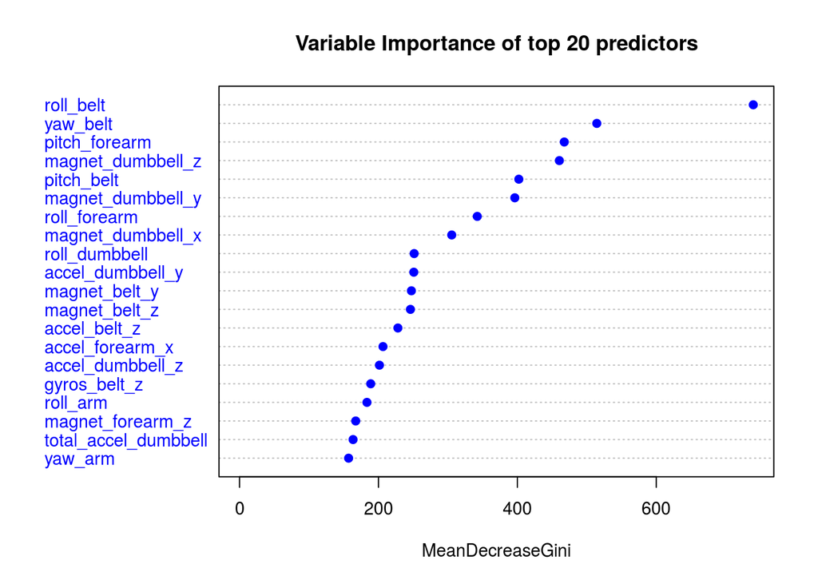

```r
varImpPlot(fit_rfor1, n.var = 20, type = 2, col = "blue", pch = 19, cex = 0.9, main ="Variable Importance of top 20 predictors") # variable importance plot
```

The model was applied on the testing data set.

```r
# run the random forest model on the testing data
y <- predict(fit_rfor1, pml_testing)
y
```

```
##  1  2  3  4  5  6  7  8  9 10 11 12 13 14 15 16 17 18 19 20
##  B  A  B  A  A  E  D  B  A  A  B  C  B  A  E  E  A  B  B  B
## Levels: A B C D E
```

It predicted successfully all the cases (20/20) .